# Reproducible Research: Peer Assessment 1

## Loading and preprocessing the data

```r
library(readr)
myData <- read_csv("activity.zip")
```

## What is mean total number of steps taken per day?

```r
library(dplyr)
```

```r
total_steps <- myData %>%
    group_by(date) %>%
    summarise(sum_steps = sum(steps)) %>%
    ungroup()
total_steps %>%
    summarise(mean = mean(sum_steps, na.rm = TRUE), median = median(sum_steps, na.rm = TRUE))
```

```
## # A tibble: 1 x 2
##     mean median
##    <dbl>  <dbl>
## 1 10766.  10765
```

**Create a histogram with raw data**

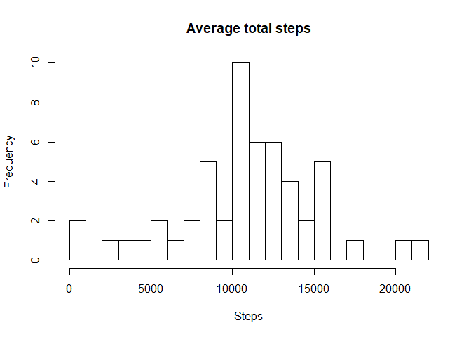

```r
hist(total_steps$sum_steps, main = "Average total steps", xlab = "Steps", breaks = 20)
```

## What is the average daily activity pattern?

```r
interval_steps <- myData %>%
    group_by(interval) %>%
    summarise(mean_steps = mean(steps, na.rm = TRUE))
interval_steps
```

```
## # A tibble: 288 x 2
##    interval mean_steps
##       <dbl>      <dbl>
##  1        0     1.72
##  2        5     0.340
##  3       10     0.132
##  4       15     0.151
##  5       20     0.0755
##  6       25     2.09
##  7       30     0.528
##  8       35     0.868
##  9       40     0
## 10       45     1.47
## # ... with 278 more rows
```

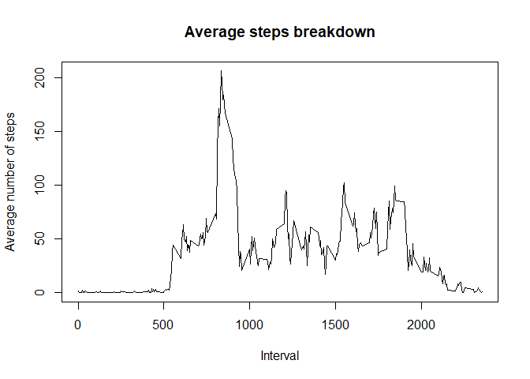

```r
plot(interval_steps$interval, interval_steps$mean_steps, type = "l", main = "Average steps breakdown", xlab = "Interval", ylab = "Average number of steps")
```

```r
interval_steps[which.max(interval_steps$mean_steps),]
```

```
## # A tibble: 1 x 2
##   interval mean_steps
##      <dbl>      <dbl>
## 1      835       206.
```

On average, across all days in the dataset, interval 835 contains the maximum number of steps, i.e., 206.1698113.

## Imputing missing values

**The total number of missing values in the dataset**

```r
length(myData[is.na(myData)])
```

```
## [1] 2304
```

**Imputing missing values by filling in the mean for that 5-minute interval**

```r
filled_data <- myData
for (i in interval_steps$interval) {
    filled_data[which(filled_data$interval == i & is.na(filled_data$steps)), "steps"] <- interval_steps[which(interval_steps$interval == i), "mean_steps"]
}
filled_total_steps <- filled_data %>% group_by(date) %>% summarise(sum_steps = sum(steps)) %>% ungroup()
filled_total_steps %>% summarise(mean_steps = mean(sum_steps), median_steps = median(sum_steps))
```

```
## # A tibble: 1 x 2
##   mean_steps median_steps
##        <dbl>        <dbl>
## 1     10766.       10766.
```

After imputing missing values with the mean for each 5-minute interval, there is no change to the mean and a slight (minor) change to the median of the dataset.

**Create a histogram with imputed data**

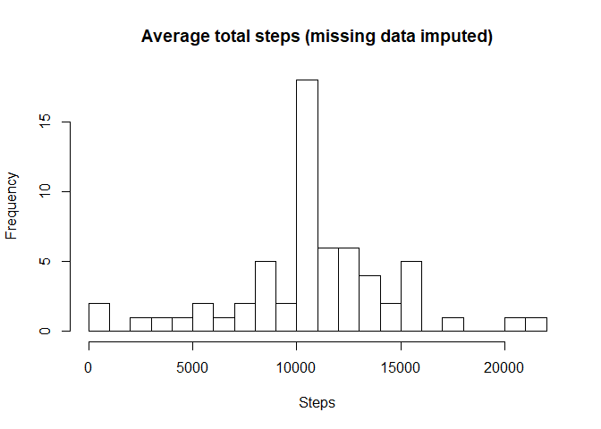

```r
hist(filled_total_steps$sum_steps, main = "Average total steps (missing data imputed)", xlab = "Steps", breaks = 20)
```

Comparing the two histograms, the general shapes of the two are same. The only difference is the frequency of the *mean* value due to the method of imputation.

## Are there differences in activity patterns between weekdays and weekends?

**Categorizing dates into weekdays and weekends**

```r
filled_data <- filled_data %>% mutate(category = factor(ifelse(weekdays(date) %in% c("Saturday", "Sunday"), "weekends", "weekdays")))
head(filled_data)
```

```
## # A tibble: 6 x 4
##    steps date       interval category
##    <dbl> <date>        <dbl> <fct>
## 1 1.72   2012-10-01        0 weekdays
## 2 0.340  2012-10-01        5 weekdays
## 3 0.132  2012-10-01       10 weekdays
## 4 0.151  2012-10-01       15 weekdays
## 5 0.0755 2012-10-01       20 weekdays
## 6 2.09   2012-10-01       25 weekdays
```

**Create a panel plot**

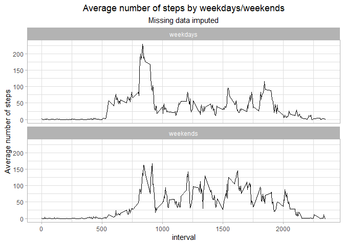

```r
library(ggplot2)
filled_data %>%
    group_by(interval, category) %>%
    summarise(mean_steps = mean(steps)) %>%
    ggplot(aes(x = interval, y = mean_steps)) + geom_line() + facet_wrap(facets = vars(category),
    nrow = 2) + theme_light() + ylab("Average number of steps") + ggtitle("Average number of steps by weekdays/weekends",
    subtitle = "Missing data imputed") + theme(plot.title = element_text(hjust = 0.5),
    plot.subtitle = element_text(hjust = 0.5))
```

There’s a general pattern that during weekdays, a lot of steps are taken between 8-10 AM whereas the steps are more evenly spread during the weekends.